# Lab 2: Enrichment Analyses

BMI 206

Answer Key

Import needed packages and set a random number seed

```r
#load packages
library(regioneR)
library(ggplot2) # for plotting
library(dplyr)
set.seed(10)
```

Read in BED formatted region files: all tested regions and two sets of positives Note: these are in hg19 human genome assembly coordinates

```r
all <- toGRanges(read.table("all.bed",sep="\t"))
hits1 <- toGRanges(read.table("hits1.bed",sep="\t"))
hits2 <- toGRanges(read.table("hits2.bed",sep="\t"))
```

**Q1. How many regions are in hits1? How many in hits2?**

```r
n_regions1 <- nrow(toDataframe(hits1))
n_regions2 <- nrow(toDataframe(hits2))
```

There are 140 regions in `hits1` and 322 regions in `hits2`.

**Q2. Are hits1 and hits2 proper subsets of all the tested regions? Check how many of each set overlaps a region in all.**

```r
numOverlaps(hits1, all, count.once=TRUE)
```

```
## [1] 140
```

```r
numOverlaps(hits2, all, count.once = TRUE)
```

```
## [1] 322
```

```r
numOverlaps(hits1, all)
```

```
## [1] 141
```

```r
numOverlaps(hits2, all)
```

```
## [1] 337
```

Because every region in `hits1` and `hits2` overlaps with at least one region in `all`, `hits1` and `hits2` can be considered proper subsets of `all`. Because the number of unique overlaps (`count.once=TRUE`) is less than the total number of overlaps for both `hits1` and `hits2`, we can also conclude that some of the regions appear more than once in these datasets.

The next few questions explore the overlap of genomic regions in `hits1` and `hits2`.

**Q3. How many regions overlap? How many regions are exactly identical?**

```r
# How many regions overlap?
numOverlaps(hits1, hits2)
# how many regions are exactly identical?
nrow(toDataframe(commonRegions(hits1, hits2)))
#alternative way to check exactly identical regions
#hits1[hits1%in%hits2,]
#hits2[hits2%in%hits1,]
```

There are 6 overlapping regions between `hits1` and `hits2`. There are also 6 identical regions between `hits1` and `hits2`, meaning that all of the overlapping regions are identical.

**Q4. Generate a set of random genomic regions of the same size as hits1. Match these to the mean and sd of the genomic length of the hits1 regions.**

```r
# install masked version of hg19
# BiocManager::install("BSgenome.Hsapiens.UCSC.hg19.masked")
# generate random regions same size as hits1
hits1_widths <- width(hits1)
hits1_randomized <- createRandomRegions(nregions=length(hits1),
                                    length.mean=mean(hits1_widths),
                                    length.sd=sqrt(var(hits1_widths)),
                                    mask=NULL)
```

- **Do the random genomic regions overlap hits2 more or less than hits1 does?**

```r
numOverlaps(hits1_randomized, hits2)
```

```
## [1] 0
```

There are 6 overlapping regions between `hits1` and `hits2`, and 0 overlaps between `hits2` and the randomized `hits1`. So the random regions overlap `hits2` less.

- **How much do the random genomic regions overlap all tested regions?**

```r
numOverlaps(hits1_randomized, all)
```

```
## [1] 0
```

0 times.

- **Repeatedly generate genomic regions to compute a z-score for the overlap of hits1 with hits2**

```r
perm_test <- permTest(A=hits1, ntimes = 100,
                      randomize.function = randomizeRegions,
                      evaluate.function = numOverlaps, count.once = TRUE,
                      B = hits2)
summary(perm_test)
```

```
## Permutation tests: 1
## Significant permutation tests: 1
## Iterations: 100
## Randomization Function: randomizeRegions
## Tests Results:
##                 pvalue  zscore    test
## numOverlaps 0.00990099 17.0677 greater
```

Note: This can be done a number of different ways, for example, using `overlapPermTest` or your own for-loop instead of `PermTest`. It is also equivalent to use `createRandomRegions` instead of `randomizeRegions`.  
Another note: The names of the functions `PermTest` and `overlapPermTest` are a bit misleading, because they can be used to generate random draws (i.e., bootstrapping) in addition to permuting. The argument `randomize.function` controls the type of resampling.

- **Use the set of overlaps with random regions to test the null hypothesis that hits2 overlaps hits1 more than expected compared to totally random regions.**  
  The p-value from the permutation test is `.01`, which is lower than the significance threshold of `.05`. Therefore, we can reject the null hypothesis that `hits1` and `hits2` overlap the same amount as what would be expected between `hits2` and random regions.
- **What is the smallest p-value you could have gotten?**  
  This will depend on how many permutations were performed. The lowest possible p-value will be 1 divided by the number of permutations performed plus 1: 1/(#permutations + 1). In this case, we see that our p-value is slightly less than `.01`, which is the lowest possible p-value attainable with 100 permutations.
- **How do the results change with number of resamples? Random seed?**

```r
# try a number of permutation tests between 50 and 1000 permutations
p_vals <- c()
zs <- c()
N = seq(50, 1000, 50)

for (i in N){
  perm_test <- permTest(A=hits1, ntimes = i,
                        randomize.function = randomizeRegions,
                        evaluate.function = numOverlaps, count.once = TRUE,
                        B = hits2)
  p_vals <- c(p_vals, perm_test$numOverlaps["pval"][[1]])
  zs <- c(zs, perm_test$numOverlaps["zscore"][[1]])
}
```

```
## [1] "Note: The minimum p-value with only 50 permutations is 0.0196078431372549. You should consider increasing the number of permutations."
```

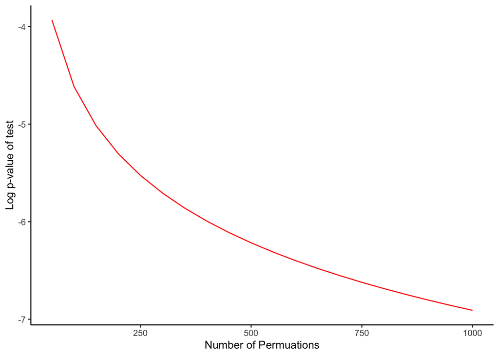

```r
# save results in a dataframe for easy access
test_results <- data.frame(N, p_vals, zs)

# plot the p-values by number of permutations
ggplot(test_results) +
  geom_line(aes(N, log(p_vals)), color="red") +
  xlab("Number of Permuations") +
  ylab("Log p-value of test") +
  theme_classic()
```

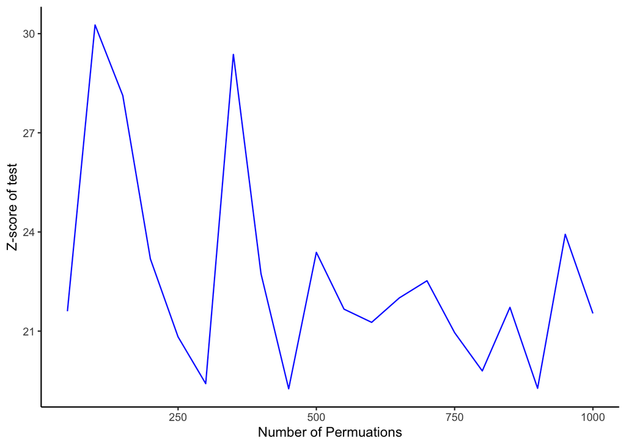

```r
# plot the z-scores by number of permutations
ggplot(test_results) +
  geom_line(aes(N, zs), color="blue") +
  xlab("Number of Permuations") +
  ylab("Z-score of test") +
  theme_classic()
```

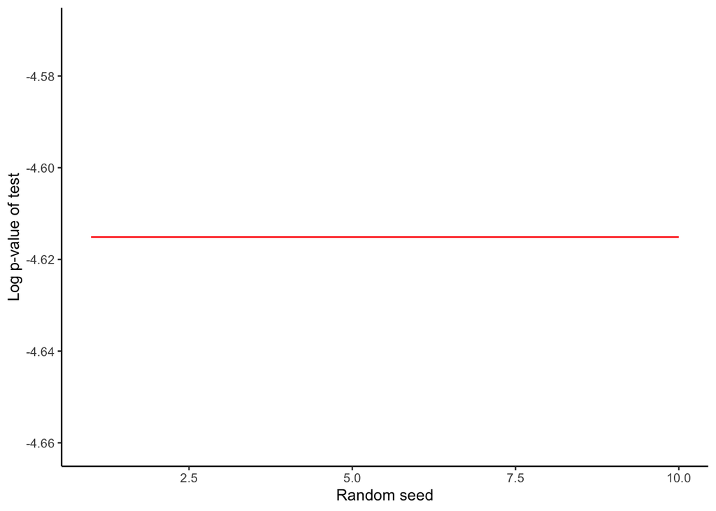

```r
# try a number of random seeds
p_vals <- c()
zs <- c()
seeds <- seq(1, 10)

for (i in seeds){
  set.seed(i)
  # use the same N value as our original test
  perm_test <- permTest(A=hits1, ntimes = 100,
                        randomize.function = randomizeRegions,
                        evaluate.function = numOverlaps, count.once = TRUE,
                        B = hits2)
  p_vals <- c(p_vals, perm_test$numOverlaps["pval"][[1]])
  zs <- c(zs, perm_test$numOverlaps["zscore"][[1]])
}
# save results in a dataframe for easy access
test_results <- data.frame(seeds, p_vals, zs)

# plot the p-values by number of permutations
ggplot(test_results) +
  geom_line(aes(seeds, log(p_vals)), color="red") +
  xlab("Random seed") +
  ylab("Log p-value of test") +
  theme_classic()
```

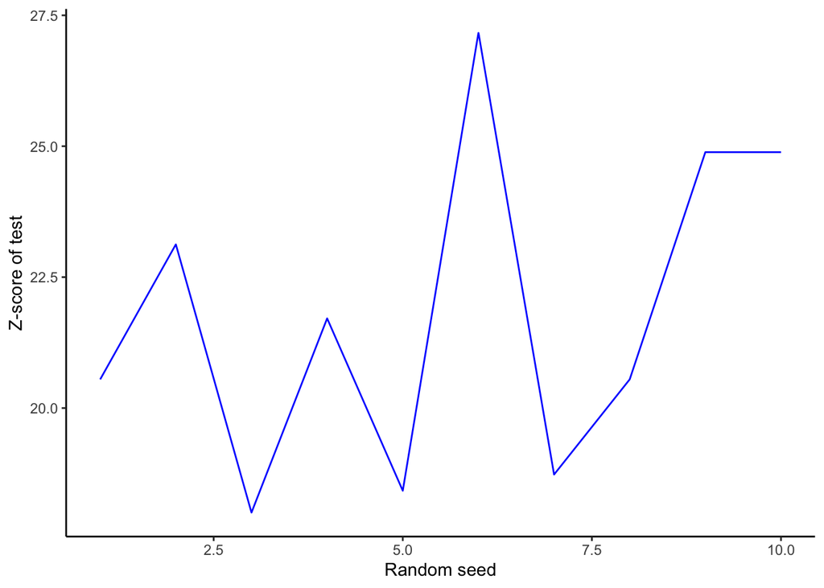

```r
# plot the z-scores by number of permutations
ggplot(test_results) +
  geom_line(aes(seeds, zs), color="blue") +
  xlab("Random seed") +
  ylab("Z-score of test") +
  theme_classic()
```

The p-values always stay at the most significant value possible. The z-scores vary slightly with different number of resamples or different seeds, but not in a way that seems systematic. That is, all of the z-scores are quite high and indicate significant deviation from the null.

**Q5. Repeat Q4 switching the roles of hits1 and hits2. Are conclusions similar?**

```r
set.seed(10)
perm_test <- permTest(A=hits2, ntimes = 100,
                      randomize.function = randomizeRegions,
                      evaluate.function = numOverlaps, count.once = TRUE,
                      B = hits1)
perm_test$numOverlaps["pval"]
```

```
## $pval
## [1] 0.00990099
```

```r
perm_test$numOverlaps["zscore"]
```

```
## $zscore
## [1] 19.2531
```

Yes, the conclusion should be the same given the low p-value and high z-score.

**Q6. Create a random bootstrap sample of regions from all tested regions.**

```r
random_bootstrap <- resampleRegions(hits1, all)
numOverlaps(random_bootstrap, hits2)
```

```
## [1] 24
```

- **Do these random regions overlap hits2 more or less than hits1 does?**  
  More. We see that `hits1` and `hits2` overlap 6 times, and the bootstrap sample and `hits2` overlap 24 times.
- **How does this test differ from the one in Q4? Look at the z-score and p-value.**

```r
# run a better bootstrap test
boot_test <- permTest(A=hits1, B=hits2,
               ntimes=100,
               randomize.function=resampleRegions,
               universe=all,
               evaluate.function=numOverlaps)
summary(boot_test)
```

```
## Permutation tests: 1
## Significant permutation tests: 1
## Iterations: 100
## Randomization Function: resampleRegions
## Tests Results:
##                 pvalue  zscore test
## numOverlaps 0.00990099 -4.0319 less
```

Now we are sampling only from our known regions `all`, not the entirety of the hg19 human genome assembly. We are also not matching by mean region length. Our “universe” is much smaller and defined. This is reflected in the dramatically reduced z-score compared to the permutation test using hg19 above. This suggests `all` is more similar to the hits than the whole genome is. In other words, the elements in `all` are not random regions of hg19.

**Q7. Repeat Q6 switching the role of hits1 and hits2. Are conclusions similar?**

```r
# run a better bootstrap test
boot_test2 <- permTest(A=hits2, B=hits1,
               ntimes=100,
               randomize.function=resampleRegions,
               universe=all,
               evaluate.function=numOverlaps)
summary(boot_test2)
```

```
## Permutation tests: 1
## Significant permutation tests: 1
## Iterations: 100
## Randomization Function: resampleRegions
## Tests Results:
##                 pvalue  zscore test
## numOverlaps 0.00990099 -4.3152 less
```

Yes, similar but not exact. We get a slightly lower z-score, perhaps because `hits2` is a larger set.

**Q8. Which null distribution would you use in your own research and why?**  
It would depend on the question. If you were interested in how often these two, separate genome-wide assays returned the same regions you would use the permutation test with hg19. You would probably want to spend time to match it better as a null (masking repetitive regions, etc). If you were interested in whether `hits1` and `hits2` are different from other regions in `all`, you would use bootstrap sampling from `all`. Or you could repeat the permutation test but only generating random regions from the possible bounds of `all` (if you knew how `all` was defined, which you do not know here).

The next few questions involve downloading genomics data. You can choose sets of regions, e.g, gene annotation, ChIPseq, RNAseq, ATACseq, GWAS SNPs. The code below shows examples of how to look for associations, but there are many ways you could do this. Most of the output of the code is suppressed because it takes a long time to run.

**Q9. Using data you download, can you infer what function was tested in the assay that discovered hits1 and hits2? Choose data sets that will be informative about candidate functions. Compute overlaps or mean values of the downloaded data for the union of hits1 and hits2**  
First, look at the sizes of the regions.

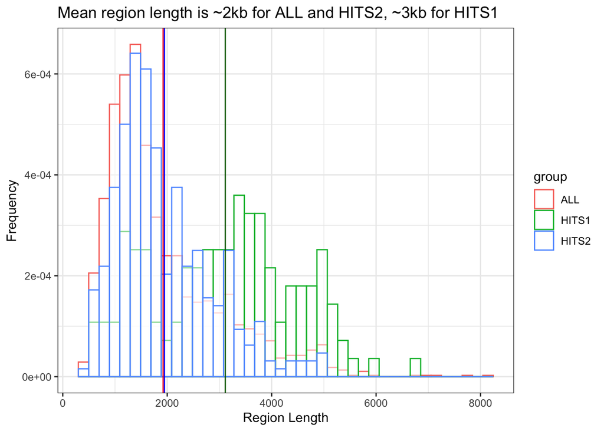

```r
a <- data.frame("length" = c(width(all), width(hits1), width(hits2)),
                "group" = c(rep("ALL", length(all)), rep("HITS1", length(hits1)), rep("HITS2", length(hits2)))
)
#table(a$group)
ggplot(a, aes(x=length, color=group)) +
  geom_histogram(aes(y=..density..), fill="white", alpha=0.5, position="identity", bins = 40) +
  theme_bw() +
  geom_vline(xintercept = mean(a[a$group == "ALL", "length"]), color="red") +
  geom_vline(xintercept = mean(a[a$group == "HITS1", "length"]), color="darkgreen") +
  geom_vline(xintercept = mean(a[a$group == "HITS2", "length"]), color="blue") +
  xlab("Region Length") + ylab("Frequency") +
  ggtitle("Mean region length is ~2kb for ALL and HITS2, ~3kb for HITS1")
```

Some of the genomic features you may want to explore are RNA, narrow peak ChIPseq (e.g., transcription factor binding), broad peak ChIPseq (e.g., repressive histone marks), and annotations of nearby genes.

```r
library(ChIPpeakAnno) #try loading here
library(TxDb.Hsapiens.UCSC.hg19.knownGene)
hits = c(hits1,hits2)
aCR<-ChIPpeakAnno::assignChromosomeRegion(all, nucleotideLevel=FALSE,
                            precedence=c("Promoters", "immediateDownstream",
                                         "fiveUTRs", "threeUTRs",
                                         "Exons", "Introns"),
                           TxDb=TxDb.Hsapiens.UCSC.hg19.knownGene)
aCR_hits<-ChIPpeakAnno::assignChromosomeRegion(hits, nucleotideLevel=FALSE,
                            precedence=c("Promoters", "immediateDownstream",
                                         "fiveUTRs", "threeUTRs",
                                         "Exons", "Introns"),
                           TxDb=TxDb.Hsapiens.UCSC.hg19.knownGene)

par(mfrow=c(2,1))
barplot(aCR$percentage, main="All: majority of regions are intergenic/intronic == non-coding")
barplot(aCR_hits$percentage, main="Same pattern for HITS")
```

Our hits are mostly in intergenic regions. Next, examine how close they are to gene transcription start sites (TSS).

```r
annoData <- suppressMessages(toGRanges(TxDb.Hsapiens.UCSC.hg19.knownGene, feature="gene"))

annotatedPeak_all <- annotatePeakInBatch(all, AnnotationData = annoData)
annotatedPeak_all <- addGeneIDs(annotatedPeak_all, orgAnn="org.Hs.eg.db", IDs2Add=c("symbol"), feature_id_type="entrez_id")
annotatedPeak_hits1 <- annotatePeakInBatch(hits1, AnnotationData = annoData)
annotatedPeak_hits1 <- addGeneIDs(annotatedPeak_hits1, orgAnn="org.Hs.eg.db", IDs2Add=c("symbol"), feature_id_type="entrez_id")
annotatedPeak_hits2 <- annotatePeakInBatch(hits2, AnnotationData = annoData)
annotatedPeak_hits2 <- addGeneIDs(annotatedPeak_hits2, orgAnn="org.Hs.eg.db", IDs2Add=c("symbol"), feature_id_type="entrez_id")

mean(annotatedPeak_all$distancetoFeature)
table(annotatedPeak_all$insideFeature)
```

```r
#Define some functions
quick_GO <- function(annotatedPeak){
  over <- getEnrichedGO(annotatedPeak, orgAnn="org.Hs.eg.db",
                    maxP=0.01, minGOterm=10,
                    multiAdjMethod="BH",
                    condense=FALSE, feature_id_type = "entrez_id")
  final <- rbind(unique(over[["bp"]][, c(1,2,4,5)]),
                 unique(over[["mf"]][, c(1,2,4,5)]),
                 unique(over[["cc"]][, c(1,2,4,5)]))
  #note, dont take into account background, length, etc,
  #not correcting for a lot of things I should in theory.
  final$log10pval <- -log10(final$pvalue)
  final  <- final %>% arrange(pvalue)
  return(final)
}

GOplot <- function(df, my.title, my.n=20, my.col="#08589E"){
  df <- head(df, n=my.n)
  df <- df %>% arrange(log10pval)
  df$go.term <- factor(df$go.term, levels = df$go.term) # so it holds same order as df

  g2 <- ggplot(data=df, aes(x=go.term, y=log10pval, fill="Gene")) +
    geom_bar(stat="identity") +
    ylab("-log10(padj)") +
    xlab("") +
    ggtitle(my.title) +
    coord_flip() +
    scale_fill_manual(values=c(my.col)) +
    geom_text(aes(label = Ontology), hjust = 1.5, color = "white", size = 3) +
    theme(axis.text.x = element_text(size=10), legend.position="none") +
    labs(fill='Gene Ontology Grouping')
  return(g2)
}

#Gene ontology on all regions given
go_all <- quick_GO(annotatedPeak_all)
go_hits1 <- quick_GO(annotatedPeak_hits1)
go_hits2 <- quick_GO(annotatedPeak_hits2)

GOplot(go_all, "ALL: go enrichment")
GOplot(go_hits1, "HITS1: go enrichment", my.col = "salmon")
GOplot(go_hits2, "HITS2: go enrichment", my.col = "darkgreen")
```

This indicates some different terms for `hits1` versus `hits2`. Maybe they function in different tissues.

**Guess what type of genomic element these hits are (i.e., what assay was performed))**  
A reasonable guess: This is ChIP seq pull down of a transcription factor in heart and some brain-type cell.  
Answer: This is a good guess. The true answer is that these regions tested for enhancer activity using transient transgenic mouse assays, downloaded from the VISTA Enhancer Browser. The file `all` includes all tested regions at the time of download, which encompasses negatives (no enhancer activity) and regions positive for activity in different tissues. The elements in `all` were prioritized for the assay based on evolutionary conservation and epigenetic marks. The regions in `hits1` are limb enhancers (limb does include muscle, and hence the heart GO terms), whereas the regions in `hits2` are brain enhancers.

**BONUS Q11: Try matching the random regions more closely to regions in hits1**  
- On what variables will you match them? e.g., spacing, chromosome, GC-content, distance to nearest gene, masking  
- How does matching affect the z-score and p-value?

You could leverage another R package (gapped-kmer-SVM classifier) that was built to generate a matched set of regions by GC content (tolerates 0.02 deviation from input), repeat regions (tolerates 0.02 deviation), and region length (again, 0.02 deviation) and outputs a list of the same length (xfold=1). To save time during rendering, you can generate a matched list larger than `hits1` (xfold=5 so ~700 regions) and then randomly sample from that as the “universe”. Otherwise it would be necessary to run the svm every iteration which is a lot of computation.